# Comparison Opal and ActiGraph in MobGap pipeline

## Specifications

Opal

- 3-axis accelerometer
- 3-axis gyroscope
- 3-axis magnetometer
- 128 Hz sampling frequency
- accelerometer range is +-58.8 m/s^2
- The X and Y axis gyros have a range of +-34:9 rad/s (2000 dps)
- The Z axis gyro has a range of +-26:8 rad/s (1500 dps)
- Magnetometers have a range of +-6 Gauss

ActiGraph

- 3-axis accelerometer
- 30 Hz sampling frequency
- range +-8G

# Concerns

- Low sampling frequency
  - Aliasing of high frequency components
- Lack of gyroscope
  - Sensor fusion for orientation estimation cannot be used

## Low sampling rate

Sampling a high frequency component (red) at a low sampling rate will cause the high frequency component to look like a low frequency component (blue).

This could get mixed up with real low-frequency components.

Additionally, when we then low-pass the data, it might become distorted.

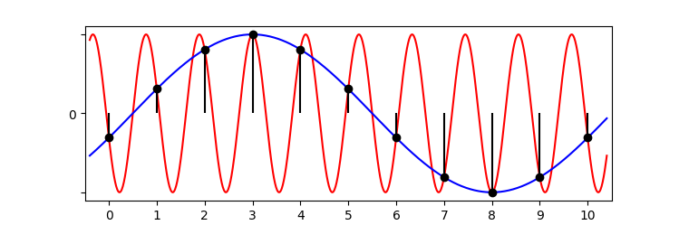

## Low sampling rate

This might not be such a large problem in gait data.

There is a lot of power concentrated to below 15 Hz.

See articles:

https://alkvi.github.io/imu_comparison/#frequency-components-of-gait

## Orientation estimation

The MobGap implementation uses the [Madgwick filter](https://doi.org/10.1109/ICORR.2011.5975346) to estimate global frame orientation, to better estimate stride length and walking speed.

This requires a gyroscope (and preferably a magnetometer).

The ActiGraph does not have this.

However, to at least counteract variations in ActiGraph placement, the vertical axis could be aligned with gravity before each gait sequence, if we detect a stable period before the gait sequence.

For example using something like Moe-Nilssen 1998.